# HW5

## Breast Histopathology Images Classification with CNNs and Variants

### *Kun Tao*

Convolutional neural networks (CNNs) are well suited for image recognition. In this work, speeded up by GPU supported by the Google Colab, CNNs with/without Batch Normalization, Data Augmentation and Residual Connections built with Keras on TensorFlow are trained with 39393 subsampled, balanced non-IDC or IDC Breast Histopathology Images first, then applied to 13131 test images and obtained a test accuracy of 84.2%.

```python
import numpy as np
import pandas as pd
import random
import warnings
import gc

import os
import tensorflow as tf
os.environ['TF_CPP_MIN_LOG_LEVEL'] = '3'

import json
import cv2

from sklearn.datasets import load_iris
from keras.datasets import fashion_mnist

from sklearn.preprocessing import StandardScaler
from sklearn.model_selection import train_test_split
from sklearn.model_selection import StratifiedShuffleSplit
from sklearn.model_selection import GridSearchCV

import keras
from keras.models import Sequential, Model
from keras import regularizers
from keras.layers import Dense, Activation, Dropout, BatchNormalization
from keras.layers import Conv2D, MaxPooling2D, Flatten, Input, add
from keras.preprocessing import image
from keras.preprocessing.image import ImageDataGenerator

from keras.optimizers import Adam

from keras.wrappers.scikit_learn import KerasClassifier

from glob import glob

from imblearn.under_sampling import RandomUnderSampler

%matplotlib inline
import matplotlib.pyplot as plt
```

**Train a convolutional neural network on the following dataset: https://www.kaggle.com/paultimothymooney/breast-histopathology-images**

In order to load the dataset 'IDC_regular_ps50_idx5.zip' into Colab, I first uploaded it into my Google Drive, then downloaded and unzipped it to my newly created directory 'task3_data' in the 'Files' section of Colab.

Next, get filename lists 'images_class0' and 'images_class1'. As we see, there are 198738 images in class 0 and 78786 images in class 1. To avoid crashing the GPU after reading the images into Colab, I took a subsample from the original data and meanwhile kept the ratio of class 0 to class 1, that is, randomly read 66246 images from class 0 and 26262 images from class 1 to obtain (X_imgs, y) from which I further generated a balanced subsample (X_imgs_bal, y_bal) by using RandomUnderSampler. The balanced subsample includes 52524 images, and class 0 and class 1 each has 26262 images.

To make sure nothing was wrong during the above sampling preprocessing, two random images are respectively picked from the imbalanced X_imgs and the balanced X_imgs_bal, and displayed in Figure 2 and 3 below.

Then, I split (X_imgs_bal, y_bal) into X_train_imgs, X_test_imgs, y_train, y_test, and further applied necessary preprocessing to them. Again, to make sure nothing was worng, I randomly picked two images from X_train_imgs and displayed them in Figure 4 below.

To compare the effect of batch normalization, in 3.1 a), I first built a convolutional neural network (CNN) without batch normalization, then in 3.1 b), I developed a CNN with batch normalization. After trial and error, I set the 'filters' in the Conv2D as 8, and in the 'fit' method, I set batch_size=128, epochs=50 and validation_split=.2 for both models, and further changed the learning rate of the Adam optimizer from the default 0.001 to 0.0001. The combination of these settings not only greatly reduced the wild fluctuations of the validation curve in my initial experiments, but also speed up the training of the required CNN. The learning curves for these two models are shown in Figure 5 and Figure 6, and both look pretty reasonable.

The accuracy scores evaluated on ( X_test_imgs, y_test) are as follows:

## CNN with/without Batch Normalization

> **CNN without Batch Normalization:**
- Test loss of CNN without Batch Normalization: 0.415
- Test accuracy of CNN without Batch Normalization: 0.813

> **CNN with Batch Normalization:**
- Test loss of CNN with Batch Normalization: 0.389
- Test accuracy of CNN with Batch Normalization: 0.838

As we see batch normalization does help here. After using it , the test accuracy is improved by 0.838 - 0.813 = 0.025.

## CNN with Data Augmentation

In this subtask, settings in the ImageDataGenerator, fit_generator and evaluate_generator are chosen based on the examples shown at the Keras ' Image Preprocessing' webpage, as well as my own trial and error. Also, I used train_test_split to explicitly split the (X_train_imgs, y_train) into X_train_imgs_aug, X_val_imgs_aug, y_train_aug, y_val_aug, and the (X_val_imgs_aug, y_val_aug) was used for the val_generator which was further used in the fit_generator later. The test loss and accuracy of the data augmented by rotations, mirroring and other transformations are:

- Test loss of CNN with Data Augmentation: 0.384
- Test accuracy of CNN with Data Augmentation: 0.831

Compared with the CNN model without batch normalization, the test accuracy of the CNN with data augmentation is improved by 0.831 - 0.813 = 0.018. Compared to the CNN with batch normalization, the test accuracy of the CNN with augmented data is slightly lower.

Also, the learning curves of the CNN with Data Augmentation are shown in Figure 7.

## Deep CNN with or without Residual Connections

- Test loss of a deep CNN with Residual Connections: 0.378
- Test accuracy of a deep CNN with Residual Connections: 0.842

Then, I built another model with the same architecture but without using Residual Connections. The learning curves are shown in Figure 9 and the test loss and accuracy are:

- Test loss of a deep CNN without Residual Connections: 0.693
- Test accuracy of a deep CNN without Residual Connections: 0.500

As we see, the model without using Residual Connections only has a test accuracy of 0.5, which is equivalent to the performance of random guesses in terms of the balanced subsample data used for Task 3, in other words, it already lost the ability to learn.

```python
!pip install -U -q PyDrive

from pydrive.auth import GoogleAuth
from pydrive.drive import GoogleDrive
from google.colab import auth
from oauth2client.client import GoogleCredentials

# 1. Authenticate and create the PyDrive client.
auth.authenticate_user()
gauth = GoogleAuth()
gauth.credentials = GoogleCredentials.get_application_default()
drive = GoogleDrive(gauth)

download = drive.CreateFile({'id': '1nKjDuaBfbgCWxzms9vGgEQjAuaAEZ5mS'})
download.GetContentFile('IDC_regular_ps50_idx5.zip')
```

```
    100% |████████████████████████████████| 993kB 23.8MB/s
```

```python
!mkdir 'task3_data'
!unzip IDC_regular_ps50_idx5.zip -d 'task3_data/'
```

```python
images_class0 = glob('task3_data/**/*class0.png', recursive=True)

print("len(images_class0): {}".format(len(images_class0)))
print("Example filenames in images_class0:")
for filename0 in images_class0[0:3]:
    print(filename0)


images_class1 = glob('task3_data/**/*class1.png', recursive=True)

print("\nlen(images_class1): {}".format(len(images_class1)))
print("Example filenames in images_class1:")
for filename1 in images_class1[0:3]:
    print(filename1)
```

```
len(images_class0): 198738
Example filenames in images_class0:
task3_data/9228/0/9228_idx5_x1351_y201_class0.png
task3_data/9228/0/9228_idx5_x1701_y1451_class0.png
task3_data/9228/0/9228_idx5_x1601_y1851_class0.png

len(images_class1): 78786
Example filenames in images_class1:
task3_data/9228/1/9228_idx5_x1301_y1951_class1.png
task3_data/9228/1/9228_idx5_x1201_y1801_class1.png
task3_data/9228/1/9228_idx5_x1101_y2001_class1.png
```

```
len(img_class0_imb): 66246
len(img_class1_imb): 26262

X_imgs.shape: (92508, 50, 50, 3)
y.shape: (92508,)
np.bincount(y): [66246 26262]

X_imgs_bal.shape: (52524, 50, 50, 3)
y_bal.shape: (52524,)
np.bincount(y_bal): [26262 26262]
```

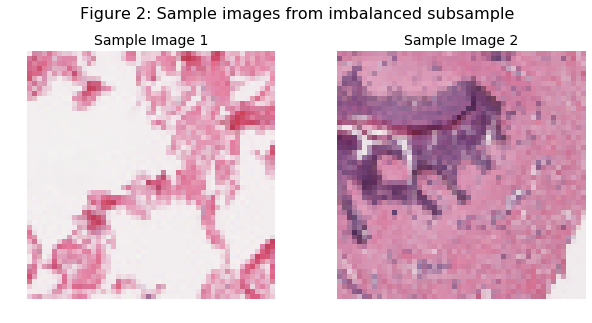

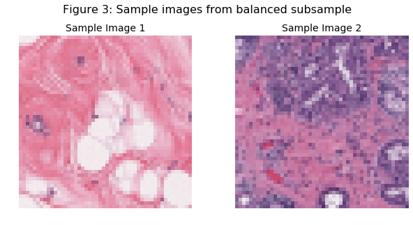

```python
random.seed(100)

num_class0 = 198738
num_class1 = 78786

num_smp_class0 = 66246
num_smp_class1 = 26262

c0 = list(range(0, num_class0))
c1 = list(range(0, num_class1))

idx_smp0_imb = random.sample(c0, num_smp_class0)
idx_smp1_imb = random.sample(c1, num_smp_class1)

img_class0_imb = []
for i in idx_smp0_imb:
  img_class0_imb.append(images_class0[i])

print("len(img_class0_imb): {}".format(len(img_class0_imb)))


img_class1_imb = []
for i in idx_smp1_imb:
  img_class1_imb.append(images_class1[i])

print("len(img_class1_imb): {}\n".format(len(img_class1_imb)))



theW = 50
theH = 50
theChannel = 3

X_imgs = []
y = []

for img in img_class0_imb:
  img_orig = cv2.imread(img)
  X_imgs.append(cv2.resize(img_orig, (theW, theH), \
                           interpolation=cv2.INTER_CUBIC))
  y.append(0)

for img in img_class1_imb:
  img_orig = cv2.imread(img)
  X_imgs.append(cv2.resize(img_orig, (theW, theH), \
                           interpolation=cv2.INTER_CUBIC))
  y.append(1)


X_imgs = np.asarray(X_imgs)
y = np.asarray(y)
print("X_imgs.shape: {}".format(X_imgs.shape))
print("y.shape: {}".format(y.shape))
print("np.bincount(y): {}\n".format(np.bincount(y)))


nrowsFig2 = 1
ncolsFig2 = 2
fig2, ax = plt.subplots(nrowsFig2, ncolsFig2, figsize=(10, 5))
fig2.subplots_adjust(wspace = 0.25, hspace=0.3, top=0.90)
fig2.suptitle('Figure 2: Sample images from imbalanced subsample', fontsize=16)

img1 = X_imgs[1000]
img1 = cv2.cvtColor(img1, cv2.COLOR_BGR2RGB)
ax[0].imshow(img1)
ax[0].axis('off')
ax[0].set_title("Sample Image 1", fontsize=14)

img2 = X_imgs[9000]
img2 = cv2.cvtColor(img2, cv2.COLOR_BGR2RGB)
ax[1].imshow(img2)
ax[1].axis('off')
ax[1].set_title("Sample Image 2", fontsize=14)


X_imgs_2d = np.reshape(X_imgs, (X_imgs.shape[0], theW * theH * theChannel))

rus = RandomUnderSampler(random_state=0, replacement=False)
X_imgs_2d_bal, y_bal = rus.fit_sample(X_imgs_2d, y)


X_imgs_bal = np.reshape(X_imgs_2d_bal, \
                        (X_imgs_2d_bal.shape[0], theW, theH, theChannel))
print("X_imgs_bal.shape: {}".format(X_imgs_bal.shape))
print("y_bal.shape: {}".format(y_bal.shape))
print("np.bincount(y_bal): {}\n".format(np.bincount(y_bal)))



del X_imgs
del y
del X_imgs_2d
del X_imgs_2d_bal
gc.collect()


nrowsFig3 = 1
ncolsFig3 = 2
fig3, ax = plt.subplots(nrowsFig3, ncolsFig3, figsize=(10, 5))
fig3.subplots_adjust(wspace = 0.25, hspace=0.3, top=0.90)
fig3.suptitle('Figure 3: Sample images from balanced subsample', fontsize=16)

img3 = X_imgs_bal[2500]
img3 = cv2.cvtColor(img3, cv2.COLOR_BGR2RGB)
ax[0].imshow(img3)
ax[0].axis('off')
ax[0].set_title("Sample Image 1", fontsize=14)

img4 = X_imgs_bal[6000]
img4 = cv2.cvtColor(img4, cv2.COLOR_BGR2RGB)
ax[1].imshow(img4)
ax[1].axis('off')
ax[1].set_title("Sample Image 2", fontsize=14)
```

```
X_train_imgs.shape: (39393, 50, 50, 3)
X_test_imgs.shape: (13131, 50, 50, 3)

y_train.shape: (39393, 2)
y_test.shape: (13131, 2)
```

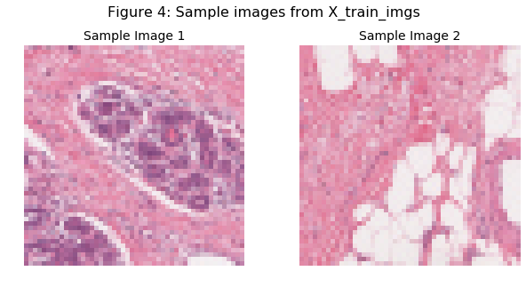

```python
warnings.simplefilter(action='ignore', category=FutureWarning)
tf.logging.set_verbosity(tf.logging.ERROR)



X_train_imgs, X_test_imgs, \
y_train, y_test = train_test_split(X_imgs_bal, y_bal, \
                                   stratify=y_bal, \
                                   random_state=0)

X_train_imgs = X_train_imgs.astype('float32')
X_test_imgs = X_test_imgs.astype('float32')
X_train_imgs /= 255
X_test_imgs /= 255


num_classes_idc = 2
y_train = keras.utils.to_categorical(y_train, num_classes_idc)
y_test = keras.utils.to_categorical(y_test, num_classes_idc)
print("X_train_imgs.shape: {}".format(X_train_imgs.shape))
print("X_test_imgs.shape: {}\n".format(X_test_imgs.shape))
print("y_train.shape: {}".format(y_train.shape))
print("y_test.shape: {}\n".format(y_test.shape))


nrowsFig4 = 1
ncolsFig4 = 2
fig4, ax = plt.subplots(nrowsFig4, ncolsFig4, figsize=(10, 5))
fig4.subplots_adjust(wspace = 0.25, hspace=0.3, top=0.90)
fig4.suptitle('Figure 4: Sample images from X_train_imgs', fontsize=16)

img5 = X_train_imgs[500]
img5 = cv2.cvtColor(img5, cv2.COLOR_BGR2RGB)
ax[0].imshow(img5)
ax[0].axis('off')
ax[0].set_title("Sample Image 1", fontsize=14)

img6 = X_train_imgs[2900]
img6 = cv2.cvtColor(img6, cv2.COLOR_BGR2RGB)
ax[1].imshow(img6)
ax[1].axis('off')
ax[1].set_title("Sample Image 2", fontsize=14)


img_rows_idc, img_cols_idc = 50, 50
input_shape = (img_rows_idc, img_cols_idc, 3)
```

## Start with a model without residual connections

### a) Convolutional Neural Network (CNN) without Batch Normalization

```
_________________________________________________________________
Layer (type)                 Output Shape              Param #
=================================================================
conv2d_1 (Conv2D)            (None, 48, 48, 8)         224
_________________________________________________________________
max_pooling2d_1 (MaxPooling2 (None, 24, 24, 8)         0
_________________________________________________________________
conv2d_2 (Conv2D)            (None, 22, 22, 8)         584
_________________________________________________________________
max_pooling2d_2 (MaxPooling2 (None, 11, 11, 8)         0
_________________________________________________________________
conv2d_3 (Conv2D)            (None, 9, 9, 8)           584
_________________________________________________________________
max_pooling2d_3 (MaxPooling2 (None, 5, 5, 8)           0
_________________________________________________________________
flatten_1 (Flatten)          (None, 200)               0
_________________________________________________________________
dense_1 (Dense)              (None, 64)                12864
_________________________________________________________________
dense_2 (Dense)              (None, 2)                 130
=================================================================
Total params: 14,386
Trainable params: 14,386
Non-trainable params: 0
_________________________________________________________________

Test loss of CNN without Batch Normalization: 0.415
Test accuracy of CNN without Batch Normalization: 0.813
```

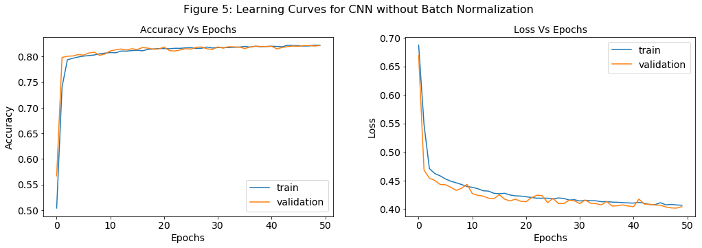

```python
cnn = Sequential()
cnn.add(Conv2D(8, kernel_size=(3, 3), \
               activation='relu', \
               input_shape=input_shape))
cnn.add(MaxPooling2D(pool_size=(2, 2), padding='same'))

cnn.add(Conv2D(8, (3, 3), activation='relu'))
cnn.add(MaxPooling2D(pool_size=(2, 2), padding='same'))

cnn.add(Conv2D(8, (3, 3), activation='relu'))
cnn.add(MaxPooling2D(pool_size=(2, 2), padding='same'))

cnn.add(Flatten())
cnn.add(Dense(64, activation='relu'))
cnn.add(Dense(num_classes_idc, activation='softmax'))

cnn.summary()

#cnn.compile("adam", "categorical_crossentropy", metrics=['accuracy'])
cnn.compile(optimizer=Adam(lr=0.0001), \
            loss='categorical_crossentropy', \
            metrics=['accuracy'])

history_cnn = cnn.fit(X_train_imgs, y_train, \
                      batch_size=128,
                      epochs=50, \
                      verbose=0, \
                      validation_split=.2)

test_score_cnn = cnn.evaluate(X_test_imgs, y_test)
print('\nTest loss of CNN without Batch Normalization: ' \
      '{:.3f}'.format(test_score_cnn[0]))

print('Test accuracy of CNN without Batch Normalization: ' \
      '{:.3f}\n'.format(test_score_cnn[1]))


pd.set_option('display.float_format', lambda x: '%.2f' % x)

nrowsFig5 = 1
ncolsFig5 = 2
fig5, ax = plt.subplots(nrowsFig5, ncolsFig5, figsize=(17, 5))
fig5.subplots_adjust(wspace = 0.25, hspace=0.3, top=0.85)
fig5.suptitle('Figure 5: Learning Curves for CNN without Batch Normalization', \
              fontsize=16)

ax[0].plot(history_cnn.history['acc'])
ax[0].plot(history_cnn.history['val_acc'])
ax[0].set_title('Accuracy Vs Epochs', fontsize=14)
ax[0].tick_params(axis='both', which='major', labelsize=14)

#ax[0].set_yticks([0.7, 0.75, 0.8, 0.85, 0.9])
#ax[0].set_yticklabels([0.7, 0.75, 0.8, 0.85, 0.9])

ax[0].set_ylabel('Accuracy', fontsize=14)
ax[0].set_xlabel('Epochs', fontsize=14)
ax[0].legend(['train', 'validation'], loc='best', fontsize=14)



ax[1].plot(history_cnn.history['loss'])
ax[1].plot(history_cnn.history['val_loss'])
ax[1].set_title('Loss Vs Epochs', fontsize=14)
ax[1].tick_params(axis='both', which='major', labelsize=14)

#ax[1].set_yticks([0.3, 0.35, 0.4, 0.45, 0.5, 0.55, 0.6])
#ax[1].set_yticklabels([0.3, 0.35, 0.4, 0.45, 0.5, 0.55, 0.6])

ax[1].set_ylabel('Loss', fontsize=14)
ax[1].set_xlabel('Epochs', fontsize=14)
ax[1].legend(['train', 'validation'], loc='best', fontsize=14)
```

### b) Convolutional Neural Network (CNN) with Batch Normalization

```
_________________________________________________________________
Layer (type)                 Output Shape              Param #
=================================================================
conv2d_1 (Conv2D)            (None, 48, 48, 8)         224
_________________________________________________________________
activation_1 (Activation)    (None, 48, 48, 8)         0
_________________________________________________________________
batch_normalization_1 (Batch (None, 48, 48, 8)         32
_________________________________________________________________
max_pooling2d_1 (MaxPooling2 (None, 24, 24, 8)         0
_________________________________________________________________
conv2d_2 (Conv2D)            (None, 22, 22, 8)         584
_________________________________________________________________
activation_2 (Activation)    (None, 22, 22, 8)         0
_________________________________________________________________
batch_normalization_2 (Batch (None, 22, 22, 8)         32
_________________________________________________________________
max_pooling2d_2 (MaxPooling2 (None, 11, 11, 8)         0
_________________________________________________________________
conv2d_3 (Conv2D)            (None, 9, 9, 8)           584
_________________________________________________________________
activation_3 (Activation)    (None, 9, 9, 8)           0
_________________________________________________________________
batch_normalization_3 (Batch (None, 9, 9, 8)           32
_________________________________________________________________
max_pooling2d_3 (MaxPooling2 (None, 5, 5, 8)           0
_________________________________________________________________
flatten_1 (Flatten)          (None, 200)               0
_________________________________________________________________
dense_1 (Dense)              (None, 64)                12864
_________________________________________________________________
dense_2 (Dense)              (None, 2)                 130
=================================================================
Total params: 14,482
Trainable params: 14,434
Non-trainable params: 48
_________________________________________________________________

Test loss of CNN with Batch Normalization: 0.389
Test accuracy of CNN with Batch Normalization: 0.838
```

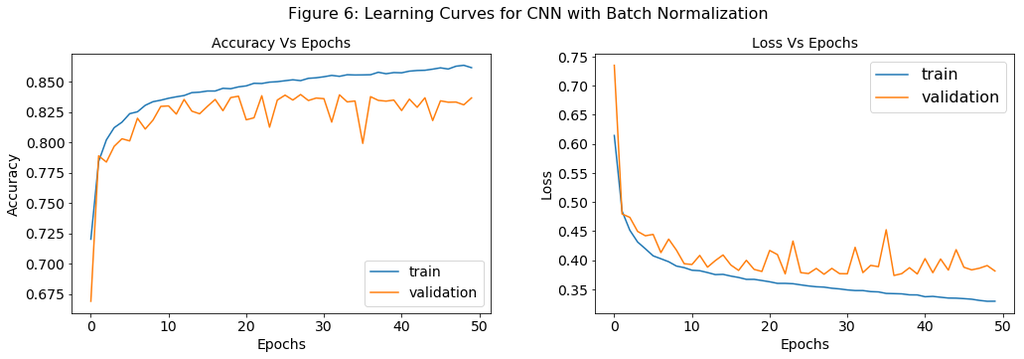

```python
cnn_bn = Sequential()
cnn_bn.add(Conv2D(8, kernel_size=(3, 3), \
                  input_shape=input_shape))
cnn_bn.add(Activation("relu"))
cnn_bn.add(BatchNormalization())
cnn_bn.add(MaxPooling2D(pool_size=(2, 2), padding='same'))
#cnn_bn.add(Dropout(.2))

cnn_bn.add(Conv2D(8, (3, 3)))
cnn_bn.add(Activation("relu"))
cnn_bn.add(BatchNormalization())
cnn_bn.add(MaxPooling2D(pool_size=(2, 2), padding='same'))
#cnn_bn.add(Dropout(.2))


cnn_bn.add(Conv2D(8, (3, 3)))
cnn_bn.add(Activation("relu"))
cnn_bn.add(BatchNormalization())
cnn_bn.add(MaxPooling2D(pool_size=(2, 2), padding='same'))
#cnn_bn.add(Dropout(.2))

cnn_bn.add(Flatten())
cnn_bn.add(Dense(64, activation='relu'))
cnn_bn.add(Dense(num_classes_idc, activation='softmax'))

#cnn_bn.compile("adam", "categorical_crossentropy", metrics=['accuracy'])
cnn_bn.compile(optimizer=Adam(lr=0.0001), \
               loss='categorical_crossentropy', \
               metrics=['accuracy'])

cnn_bn.summary()

history_cnn_bn = cnn_bn.fit(X_train_imgs, y_train, \
                            batch_size=128,
                            epochs=50, \
                            verbose=0, \
                            validation_split=.2)

test_score_cnn_bn = cnn_bn.evaluate(X_test_imgs, y_test)
print('\nTest loss of CNN with Batch Normalization: ' \
      '{:.3f}'.format(test_score_cnn_bn[0]))

print('Test accuracy of CNN with Batch Normalization: ' \
      '{:.3f}\n'.format(test_score_cnn_bn[1]))


pd.set_option('display.float_format', lambda x: '%.2f' % x)

nrowsFig6 = 1
ncolsFig6 = 2
fig6, ax = plt.subplots(nrowsFig6, ncolsFig6, figsize=(17, 5))
fig6.subplots_adjust(wspace = 0.25, hspace=0.3, top=0.85)
fig6.suptitle('Figure 6: Learning Curves for CNN with Batch Normalization', \
              fontsize=16)

ax[0].plot(history_cnn_bn.history['acc'])
ax[0].plot(history_cnn_bn.history['val_acc'])
ax[0].set_title('Accuracy Vs Epochs', fontsize=14)

ax[0].tick_params(axis='both', which='major', labelsize=14)
#ax[0].set_xticks(np.arange(0, 22, 2))
#ax[0].set_xticklabels(np.arange(0, 22, 2))

#ax[0].set_yticks([0.7, 0.75, 0.8, 0.85, 0.9])
#ax[0].set_yticklabels([0.7, 0.75, 0.8, 0.85, 0.9])

ax[0].set_ylabel('Accuracy', fontsize=14)
ax[0].set_xlabel('Epochs', fontsize=14)
ax[0].legend(['train', 'validation'], loc='best', fontsize=14)



ax[1].plot(history_cnn_bn.history['loss'])
ax[1].plot(history_cnn_bn.history['val_loss'])
ax[1].set_title('Loss Vs Epochs', fontsize=14)

ax[1].tick_params(axis='both', which='major', labelsize=14)
#ax[1].set_xticks(np.arange(0, 22, 2))
#ax[1].set_xticklabels(np.arange(0, 22, 2))

#ax[1].set_yticks([0.3, 0.35, 0.4, 0.45, 0.5, 0.55, 0.6])
#ax[1].set_yticklabels([0.3, 0.35, 0.4, 0.45, 0.5, 0.55, 0.6])

ax[1].set_ylabel('Loss', fontsize=14)
ax[1].set_xlabel('Epochs', fontsize=14)
ax[1].legend(['train', 'validation'], loc='best', fontsize=16)
```

## Augment the data using rotations, mirroring and possibly other transformations

```
X_train_imgs_aug.shape: (31514, 50, 50, 3)
y_train_aug.shape: (31514, 2)

X_val_imgs_aug.shape: (7879, 50, 50, 3)
y_val_aug.shape: (7879, 2)

X_test_imgs.shape: (13131, 50, 50, 3)
y_test.shape: (13131, 2)

_________________________________________________________________
Layer (type)                 Output Shape              Param #
=================================================================
conv2d_1 (Conv2D)            (None, 48, 48, 8)         224
_________________________________________________________________
max_pooling2d_1 (MaxPooling2 (None, 24, 24, 8)         0
_________________________________________________________________
conv2d_2 (Conv2D)            (None, 22, 22, 8)         584
_________________________________________________________________
max_pooling2d_2 (MaxPooling2 (None, 11, 11, 8)         0
_________________________________________________________________
conv2d_3 (Conv2D)            (None, 9, 9, 8)           584
_________________________________________________________________
max_pooling2d_3 (MaxPooling2 (None, 5, 5, 8)           0
_________________________________________________________________
flatten_1 (Flatten)          (None, 200)               0
_________________________________________________________________
dense_1 (Dense)              (None, 64)                12864
_________________________________________________________________
dense_2 (Dense)              (None, 2)                 130
=================================================================
Total params: 14,386
Trainable params: 14,386
Non-trainable params: 0
_________________________________________________________________

Test loss of CNN with Data Augmentation: 0.384
Test accuracy of CNN with Data Augmentation: 0.831

dict_keys(['val_loss', 'val_acc', 'loss', 'acc'])
```

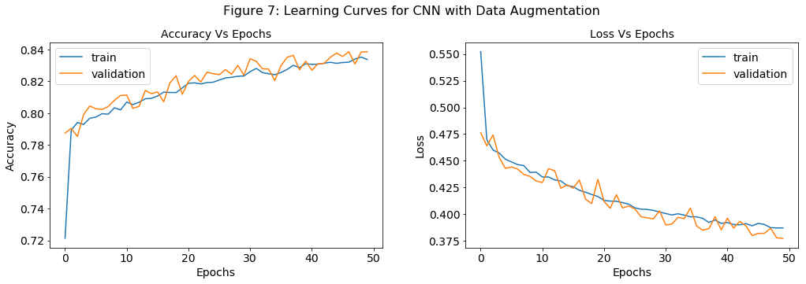

```python
X_train_imgs_aug, X_val_imgs_aug, \
y_train_aug, y_val_aug = train_test_split(X_train_imgs, y_train, \
                                          test_size=0.2, \
                                          stratify=y_train, \
                                          random_state=0)

print("X_train_imgs_aug.shape: {}".format(X_train_imgs_aug.shape))
print("y_train_aug.shape: {}\n".format(y_train_aug.shape))

print("X_val_imgs_aug.shape: {}".format(X_val_imgs_aug.shape))
print("y_val_aug.shape: {}\n".format(y_val_aug.shape))

print("X_test_imgs.shape: {}".format(X_test_imgs.shape))
print("y_test.shape: {}\n".format(y_test.shape))


datagen = ImageDataGenerator(featurewise_center=True, \
                             featurewise_std_normalization=True, \
                             rotation_range=20, \
                             zoom_range=0.2, \
                             width_shift_range=0.2, \
                             height_shift_range=0.2, \
                             shear_range=0.3, \
                             horizontal_flip=True, \
                             vertical_flip=True)

datagen.fit(X_train_imgs_aug)

val_generator = datagen.flow(X_val_imgs_aug, y_val_aug, batch_size=32)


cnn_aug = Sequential()
cnn_aug.add(Conv2D(8, kernel_size=(3, 3), \
                   activation='relu', \
                   input_shape=input_shape))
cnn_aug.add(MaxPooling2D(pool_size=(2, 2), padding='same'))

cnn_aug.add(Conv2D(8, (3, 3), activation='relu'))
cnn_aug.add(MaxPooling2D(pool_size=(2, 2), padding='same'))

cnn_aug.add(Conv2D(8, (3, 3), activation='relu'))
cnn_aug.add(MaxPooling2D(pool_size=(2, 2), padding='same'))

cnn_aug.add(Flatten())
cnn_aug.add(Dense(64, activation='relu'))
cnn_aug.add(Dense(num_classes_idc, activation='softmax'))

cnn_aug.compile(optimizer=Adam(lr=0.0001), \
                loss='categorical_crossentropy', \
                metrics=['accuracy'])

cnn_aug.summary()

history_cnn_aug = cnn_aug.fit_generator(datagen.flow(X_train_imgs_aug, \
                                                     y_train_aug, \
                                                     batch_size=32), \
                                        validation_data=val_generator, \
                                        validation_steps=len(X_val_imgs_aug)/32, \
                                        steps_per_epoch=len(X_train_imgs_aug)/32, \
                                        epochs=50, \
                                        verbose=0)

test_score_cnn_aug = cnn_aug.evaluate_generator(datagen.flow(X_test_imgs, \
                                                             y_test, \
                                                             batch_size=32), \
                                                len(X_test_imgs)/32
                                                , \
                                                2)

print('\nTest loss of CNN with Data Augmentation: ' \
      '{:.3f}'.format(test_score_cnn_aug[0]))

print('Test accuracy of CNN with Data Augmentation: ' \
      '{:.3f}\n'.format(test_score_cnn_aug[1]))



print(history_cnn_aug.history.keys())


pd.set_option('display.float_format', lambda x: '%.2f' % x)

nrowsFig7 = 1
ncolsFig7 = 2
fig7, ax = plt.subplots(nrowsFig7, ncolsFig7, figsize=(17, 5))
fig7.subplots_adjust(wspace = 0.25, hspace=0.3, top=0.85)
fig7.suptitle('Figure 7: Learning Curves for CNN with Data Augmentation', \
              fontsize=16)

ax[0].plot(history_cnn_aug.history['acc'])
ax[0].plot(history_cnn_aug.history['val_acc'])
ax[0].set_title('Accuracy Vs Epochs', fontsize=14)
ax[0].tick_params(axis='both', which='major', labelsize=14)
ax[0].set_ylabel('Accuracy', fontsize=14)
ax[0].set_xlabel('Epochs', fontsize=14)
ax[0].legend(['train', 'validation'], loc='best', fontsize=14)



ax[1].plot(history_cnn_aug.history['loss'])
ax[1].plot(history_cnn_aug.history['val_loss'])
ax[1].set_title('Loss Vs Epochs', fontsize=14)
ax[1].tick_params(axis='both', which='major', labelsize=14)
ax[1].set_ylabel('Loss', fontsize=14)
ax[1].set_xlabel('Epochs', fontsize=14)
ax[1].legend(['train', 'validation'], loc='best', fontsize=14)
```

## Build a deeper model with/without residual connections

### a) A Deep CNN Model with Residual Connections

```
Test loss of a deep CNN with Residual Connections: 0.378
Test accuracy of a deep CNN with Residual Connections: 0.842
```

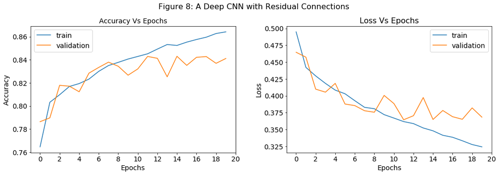

```python
inputs = Input(shape=(img_rows_idc, img_cols_idc, 3))


def addBlockII(feed):

  conv1 = Conv2D(8, (3, 3), activation='relu', padding='same')(feed)
  conv2 = Conv2D(8, (3, 3), activation='relu', padding='same')(conv1)

  return conv2


feed_in_18_resi = inputs
output_18_resi = inputs

pools_18_resi = []
convs_18_resi = []
for ii in range(1, 10):
  output_18_resi = addBlockII(feed_in_18_resi)
  convs_18_resi.append(output_18_resi)

  if ii < 9:
    maxpool_18_resi = MaxPooling2D(pool_size=(2, 2), \
                                   padding='same')(output_18_resi)
    feed_in_18_resi = maxpool_18_resi
    pools_18_resi.append(maxpool_18_resi)


maxpool_18_resi_skip = pools_18_resi[0]
conv_18_resi_skip = convs_18_resi[8]

the18_resi_skip = add([maxpool_18_resi_skip, conv_18_resi_skip])
maxpool_18_resi_in = MaxPooling2D(pool_size=(2, 2), \
                                  padding='same')(the18_resi_skip)
flat_18_resi = Flatten()(maxpool_18_resi_in)

dense_18_resi = Dense(64, activation='relu')(flat_18_resi)

predictions_18_resi = Dense(num_classes_idc, activation='softmax')(dense_18_resi)

cnn_deep_18_resi = Model(inputs=inputs, outputs=predictions_18_resi)

cnn_deep_18_resi.compile("adam", \
                         "categorical_crossentropy", \
                         metrics=['accuracy'])

#cnn_deep_18_resi.summary()

history_cnn_deep_18_resi = cnn_deep_18_resi.fit(X_train_imgs, y_train, \
                                                batch_size=128,
                                                epochs=20, \
                                                verbose=0, \
                                                validation_split=.2)

test_score_cnn_deep_18_resi = cnn_deep_18_resi.evaluate(X_test_imgs, y_test)
print('\nTest loss of a deep CNN with Residual Connections: ' \
      '{:.3f}'.format(test_score_cnn_deep_18_resi[0]))

print('Test accuracy of a deep CNN with Residual Connections: ' \
      '{:.3f}\n'.format(test_score_cnn_deep_18_resi[1]))



pd.set_option('display.float_format', lambda x: '%.2f' % x)

nrowsFig8 = 1
ncolsFig8 = 2
fig8, ax = plt.subplots(nrowsFig8, ncolsFig8, figsize=(17, 5))
fig8.subplots_adjust(wspace = 0.25, hspace=0.3, top=0.85)
fig8.suptitle('Figure 8: A Deep CNN with Residual Connections', \
              fontsize=16)

line11, = ax[0].plot(history_cnn_deep_18_resi.history['acc'])
line12, = ax[0].plot(history_cnn_deep_18_resi.history['val_acc'])
ax[0].set_title('Accuracy Vs Epochs', fontsize=14)
ax[0].tick_params(axis='both', which='major', labelsize=14)
ax[0].set_xticks(np.arange(0, 22, 2))
ax[0].set_xticklabels(np.arange(0, 22, 2))
ax[0].set_ylabel('Accuracy', fontsize=14)
ax[0].set_xlabel('Epochs', fontsize=14)
ax[0].legend((line11, line12), \
             (['train', 'validation']), \
             loc='best', fontsize=14)



line21, = ax[1].plot(history_cnn_deep_18_resi.history['loss'])
line22, = ax[1].plot(history_cnn_deep_18_resi.history['val_loss'])
ax[1].set_title('Loss Vs Epochs', fontsize=16)
ax[1].tick_params(axis='both', which='major', labelsize=14)
ax[1].set_xticks(np.arange(0, 22, 2))
ax[1].set_xticklabels(np.arange(0, 22, 2))
ax[1].set_ylabel('Loss', fontsize=14)
ax[1].set_xlabel('Epochs', fontsize=14)
ax[1].legend((line21, line22), \
             (['train', 'validation']), \
             loc='best', fontsize=14)
```

### b) A Deep CNN Model without Residual Connections

```
Test loss of a deep CNN without Residual Connections: 0.693
Test accuracy of a deep CNN without Residual Connections: 0.500
```

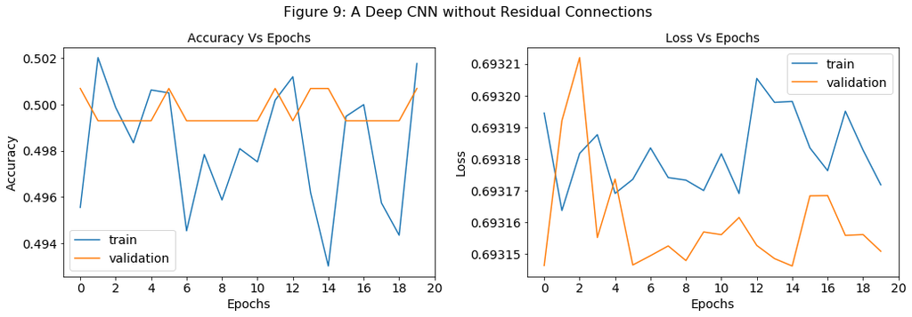

```python
inputs = Input(shape=(img_rows_idc, img_cols_idc, 3))


def addBlockI(feed):

  conv1 = Conv2D(8, (3, 3), activation='relu', padding='same')(feed)
  conv2 = Conv2D(8, (3, 3), activation='relu', padding='same')(conv1)

  maxpool = MaxPooling2D(pool_size=(2, 2), padding='same')(conv2)

  return maxpool


feed_in_18 = inputs
output_18 = inputs
for ii in range(1, 10):
  output_18 = addBlockI(feed_in_18)
  feed_in_18 = output_18

flat_18 = Flatten()(output_18)
dense_18 = Dense(64, activation='relu')(flat_18)

predictions_18 = Dense(num_classes_idc, activation='softmax')(dense_18)

cnn_deep_18 = Model(inputs=inputs, outputs=predictions_18)

#cnn_deep_18.summary()

cnn_deep_18.compile("adam", "categorical_crossentropy", metrics=['accuracy'])


history_cnn_deep_18 = cnn_deep_18.fit(X_train_imgs, y_train, \
                                      batch_size=128,
                                      epochs=20, \
                                      verbose=0, \
                                      validation_split=.2)

test_score_cnn_deep_18 = cnn_deep_18.evaluate(X_test_imgs, y_test)
print('\nTest loss of a deep CNN without Residual Connections: ' \
      '{:.3f}'.format(test_score_cnn_deep_18[0]))

print('Test accuracy of a deep CNN without Residual Connections: ' \
      '{:.3f}\n'.format(test_score_cnn_deep_18[1]))



pd.set_option('display.float_format', lambda x: '%.2f' % x)

nrowsFig9 = 1
ncolsFig9 = 2
fig9, ax = plt.subplots(nrowsFig9, ncolsFig9, figsize=(17, 5))
fig9.subplots_adjust(wspace = 0.25, hspace=0.3, top=0.85)
fig9.suptitle('Figure 9: A Deep CNN without Residual Connections', \
              fontsize=16)

line11, = ax[0].plot(history_cnn_deep_18.history['acc'], )
line12, = ax[0].plot(history_cnn_deep_18.history['val_acc'])
ax[0].set_title('Accuracy Vs Epochs', fontsize=14)
ax[0].tick_params(axis='both', which='major', labelsize=14)
ax[0].set_xticks(np.arange(0, 22, 2))
ax[0].set_xticklabels(np.arange(0, 22, 2))
ax[0].set_ylabel('Accuracy', fontsize=14)
ax[0].set_xlabel('Epochs', fontsize=14)
ax[0].legend((line11, line12), \
             (['train', 'validation']), \
             loc='best', fontsize=14)



line21, = ax[1].plot(history_cnn_deep_18.history['loss'])
line22, = ax[1].plot(history_cnn_deep_18.history['val_loss'])
ax[1].set_title('Loss Vs Epochs', fontsize=14)
ax[1].tick_params(axis='both', which='major', labelsize=14)
ax[1].set_xticks(np.arange(0, 22, 2))
ax[1].set_xticklabels(np.arange(0, 22, 2))
ax[1].set_ylabel('Loss', fontsize=14)
ax[1].set_xlabel('Epochs', fontsize=14)
ax[1].legend((line21, line22), \
             (['train', 'validation']), \
             loc='best', fontsize=14)
```